# Final Project

#### PS: the URL in line 64 can have issues when receiving several request. My IP was blocked during the development of this project. HTTP error 429. Please re run the knit for the best result

Hello! My name is Benjamin and I’m an exchange student from Chile. I spent this spring semester being an exchange student in the Computer Science department. I recently graduated so I have started searching and applying for job positions. Although the common thing would be to apply to local jobs (job positions in Chile) I’m very open to the idea of moving abroad in order to get a better quality of life. Because of this, I was curious about what country, on average, has the best purchasing power in the world. This meaning what country has the best access to services and good, and hence, has a better quality of life.

But there is one problem: It is hard to do this type of comparisons when there are so many differences between countries: population, currency, location etc. Luckily there are some transformations and assumptions that can be made to facilitate this calculation. Let’s go step by step.

First, to measure purchasing power we would need to have a list of all goods that are available within a economy and its price. Given the fact that such dataset does not exist, something that is commonly used is the Big Mac Index.

As defined by The Big Mac Index is “The Big Mac Index is published by The Economist as an informal way of measuring the purchasing power parity (PPP) between two currencies and provides a test of the extent to which market exchange rates result in goods costing the same in different countries.” [1]

In other words, we will use the Big Mac’s price across the world as a standard measurement for the price of goods in an economy. This is possible mostly because of how standarized the process of preparing a Big Mac is. Such steps are:

·Production of ingredients (price depends on local availability) ·Shipment ingredients to restaurants (price depends of international gas price and currency) ·Preparation of Big Mac on site by employee (price depends on minimum wage laws)

As a first step, we need to get dataset with relevant information about the Big Mac index. To do so, we will import some libraries that will come in handy for this task and project.

```r
library(rvest)
library(dplyr)
library(tidyr)
library(readr)
library(tidyverse)
library(stringr)
library(purrr)
library(broom)
library(stringr)
library(ggplot2)
library(ggrepel)
```

We will scrape a dataset containing information about the Big Mac index from the URL: “http://bigmacindex.org”

```r
#http://livingeconomics.org/article.asp?docId=374
mac_url <- "http://bigmacindex.org"

mac_data <- mac_url %>%
  read_html() %>%
  html_node("#tablepress-38") %>%
  html_table()

mac_data
```

| Country | Local Price | Dollar Exchange | Dollar Price | Dollar PPP | Implied Dollar Valuation |
| --- | --- | --- | --- | --- | --- |
| Argentina | 28.00 | 8.61 | 3.25 | 5.85 | -32.11 |
| Australia | 5.30 | 1.23 | 4.32 | 1.11 | -9.84 |
| Brazil | 13.50 | 2.59 | 5.21 | 2.82 | 8.70 |
| Britain | 2.89 | 0.66 | 4.37 | 0.60 | -8.81 |
| Canada | 5.70 | 1.23 | 4.64 | 1.19 | -3.14 |
| Chile | 2100.00 | 627.49 | 3.35 | 438.41 | -30.13 |
| China | 17.20 | 6.21 | 2.77 | 3.59 | -42.19 |
| Colombia | 7900.00 | 2364.98 | 3.34 | 1649.27 | -30.26 |
| Costa Rica | 2150.00 | 536.09 | 4.01 | 448.85 | -16.27 |
| Czech Republic | 70.45 | 24.13 | 2.92 | 14.71 | -39.06 |

[output cut: 47 more lines]

Now that we have scraped the data needed for the Big Mac Index, another piece of relevant information for our task is the average salarie (income) for individuals per country. We will use this value in conjunction to the Big Mac Index to compute the average purchasing power of a country.

Below we have the code needed to extract the data regarding the average income per country. This is the yearly average and monthly average salarie for an average citizen of a given country.

```r
url_wage <- "https://www.worlddata.info/average-income.php"
wage_data <- url_wage %>%
  read_html() %>%
  html_node("#tabsort") %>%
  html_table()

wage_data$Monthly = substr(wage_data$Monthly,1,nchar(wage_data$Monthly)-1)
wage_data$Monthly <- as.numeric(gsub(",","",wage_data$Monthly))
wage_data
```

| Rank | Country | Average incomeannually | Monthly |
| --- | --- | --- | --- |
| 1 | Monaco | 186,080 $ | 15507 |
| 2 | Liechtenstein | 116,300 $ | 9692 |
| 3 | Bermuda | 106,140 $ | 8845 |
| 4 | Switzerland | 81,130 $ | 6761 |
| 5 | Norway | 76,160 $ | 6347 |
| 6 | Macao | 72,050 $ | 6004 |
| 7 | Luxembourg | 70,790 $ | 5899 |
| 8 | Iceland | 60,500 $ | 5042 |
| 9 | United States | 59,160 $ | 4930 |
| 10 | Denmark | 55,330 $ | 4611 |

[output cut: 67 more lines]

Now that we have both the Big Mac Index dataset and the average wage dataset, it would be an interesting point of comparison to check how different the average in a country can be from its minimum in dollars, and how different it can be regarding purchasing power. To get some insight into this matter, we will find a dataset with this information.

Browsing the web we found that it was possible to download a .csv file containing all the information about the hourly and yearly minimum wage per country in $USD. The URL is the one shown below. Because the data is now locally stored, we have to import it.

```r
minimum_wage_url <- "https://stats.oecd.org/Index.aspx?DataSetCode=RMW"
minimum_wage_data <- read_csv("/Users/benjamimo1/Google Drive/2019-1/Intro to Data Science/project_final/hourly_minimum_wage.csv")
minimum_wage_data <- minimum_wage_data %>%
  select(COUNTRY,Time,Value,`Pay period`,SERIES)
minimum_wage_data
```

| COUNTRY | Time | Value | Pay period | SERIES |
| --- | --- | --- | --- | --- |
| IRL | 2000 | 1.564626e+04 | Annual | PPP |
| IRL | 2001 | 1.542636e+04 | Annual | PPP |
| IRL | 2002 | 1.548572e+04 | Annual | PPP |
| IRL | 2003 | 1.565366e+04 | Annual | PPP |
| IRL | 2004 | 1.676400e+04 | Annual | PPP |
| IRL | 2005 | 1.749669e+04 | Annual | PPP |
| IRL | 2006 | 1.733328e+04 | Annual | PPP |
| IRL | 2007 | 1.831688e+04 | Annual | PPP |
| IRL | 2008 | 1.795505e+04 | Annual | PPP |
| IRL | 2009 | 1.879679e+04 | Annual | PPP |

[output cut: 2232 more lines]

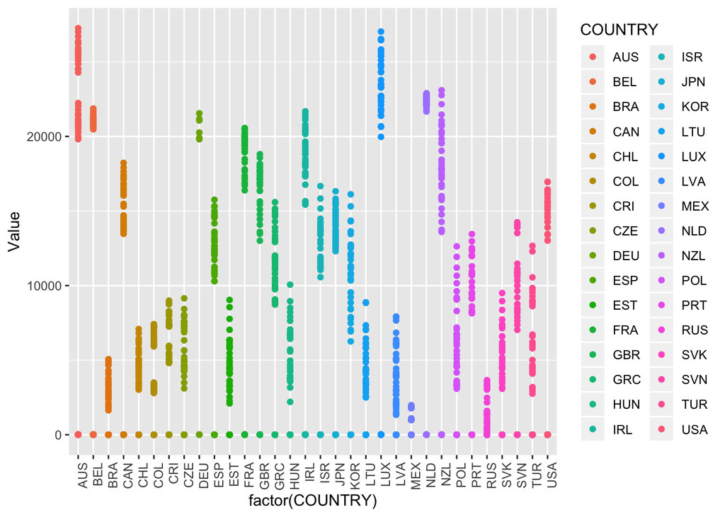

```r
minimum_wage_data %>%
  ggplot(aes(x=factor(COUNTRY), y=Value, color=COUNTRY)) + geom_point() + theme(axis.text.x = element_text(angle = 90, hjust = 1))
```

Now that we have all the data that we need, let’s tidy it up. First, we will remove some rows from minimum_wage_data, so we are only working with the latest information. For instance, we can see that we have several data entries for IRL (representing Ireland), but we know we only need one: The latest

```r
minimum_wage_data %>%
  group_by(COUNTRY, `Pay period`) %>%
  summarize(max_time=max(Time))
```

| COUNTRY | Pay period | max_time |
| --- | --- | --- |
| AUS | Annual | 2017 |
| AUS | Hourly | 2017 |
| BEL | Annual | 2017 |
| BEL | Hourly | 2017 |
| BRA | Annual | 2017 |
| BRA | Hourly | 2017 |
| CAN | Annual | 2017 |
| CAN | Hourly | 2017 |
| CHL | Annual | 2017 |
| CHL | Hourly | 2017 |

[output cut: 54 more lines]

After summarizing the latest year for each country, we find that for all of them is 2017. So we proceed to filter by that year.

```r
latest_minimum_wage_data <- filter(minimum_wage_data, Time == 2017, SERIES == 'EXR')  %>%
  arrange(desc(desc(COUNTRY)))
latest_minimum_wage_data
```

| COUNTRY | Time | Value | Pay period | SERIES |
| --- | --- | --- | --- | --- |
| AUS | 2017 | 2.725256e+04 | Annual | EXR |
| AUS | 2017 | 1.379566e+01 | Hourly | EXR |
| BEL | 2017 | 1.003190e+01 | Hourly | EXR |
| BEL | 2017 | 2.092313e+04 | Annual | EXR |
| BRA | 2017 | 1.501529e+00 | Hourly | EXR |
| BRA | 2017 | 3.523231e+03 | Annual | EXR |
| CAN | 2017 | 8.761405e+00 | Hourly | EXR |
| CAN | 2017 | 1.822372e+04 | Annual | EXR |
| CHL | 2017 | 4.993575e+03 | Annual | EXR |
| CHL | 2017 | 2.128160e+00 | Hourly | EXR |

[output cut: 53 more lines]

Big Macs per month: Given the local price and the local average/minimum salarie, if I spent all my money on Big Macs, how many would I get?

Hours per Big Mac: Given the local price and the local average/minimum salarie, how many hours does someone have to work to afford one Big Mac.

For this we will need to use data from different tables so we will do a join operation! The problem is that in some tables countries are listed according to their abbreviations and not their full names. So we searched online and found a dataset that maps countries to their abbreviation and it is what we’ll use to make our join possible

```r
country_abbreviation <- read_csv("/Users/benjamimo1/Google Drive/2019-1/Intro to Data Science/project_final/country_codes.csv")
country_abbreviation <- country_abbreviation %>%
  select(FIFA, `UNTERM English Short`) %>%
  arrange(desc(desc(FIFA)))
country_abbreviation
```

| FIFA | UNTERM English Short |
| --- | --- |
| AFG | Afghanistan |
| AIA | NA |
| ALB | Albania |
| ALD | NA |
| ALG | Algeria |
| AND | Andorra |
| ANG | Angola |
| ANT | NA |
| ARG | Argentina |
| ARM | Armenia |

[output cut: 240 more lines]

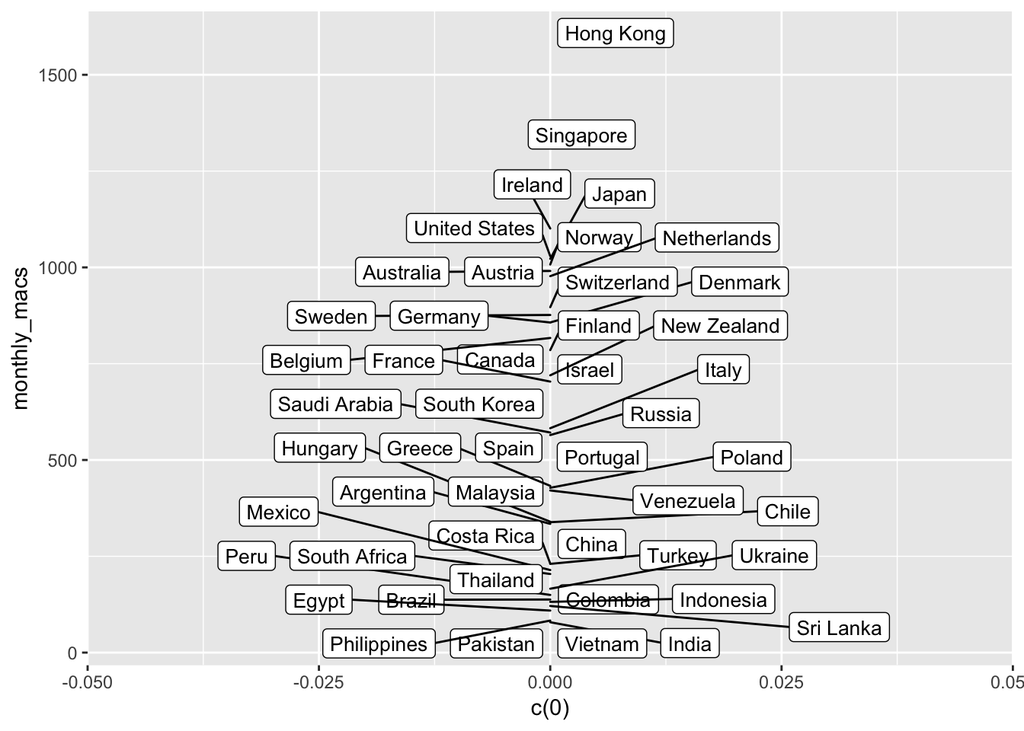

```r
#wage_data %>%
#  inner_join(country_abbreviation, by = c( Country = "UNTERM English Short"))

macXwage <- mac_data %>% inner_join(wage_data, "Country")
macXwage <- macXwage %>%
  mutate(monthly_macs = as.double(Monthly) / `Dollar Price`)

macXwage %>%
  ggplot(aes(x=c(0), y=monthly_macs, label = Country)) + geom_label_repel(size = 3.5)
```

From the graph above we can see how Hong Kong and Singapore are on the top of our metric. This means that relative to food (in this case Big Macs), people from Hong Kong have on average the highest purchasing power in the world.

Now that we have seen this result for the average citizen, what about does who are not in the middle but rather at the bottom?

Because of inconsistencies between our datasets we will do multiple joins to be able to join between countries’ full names and their abbreviation.

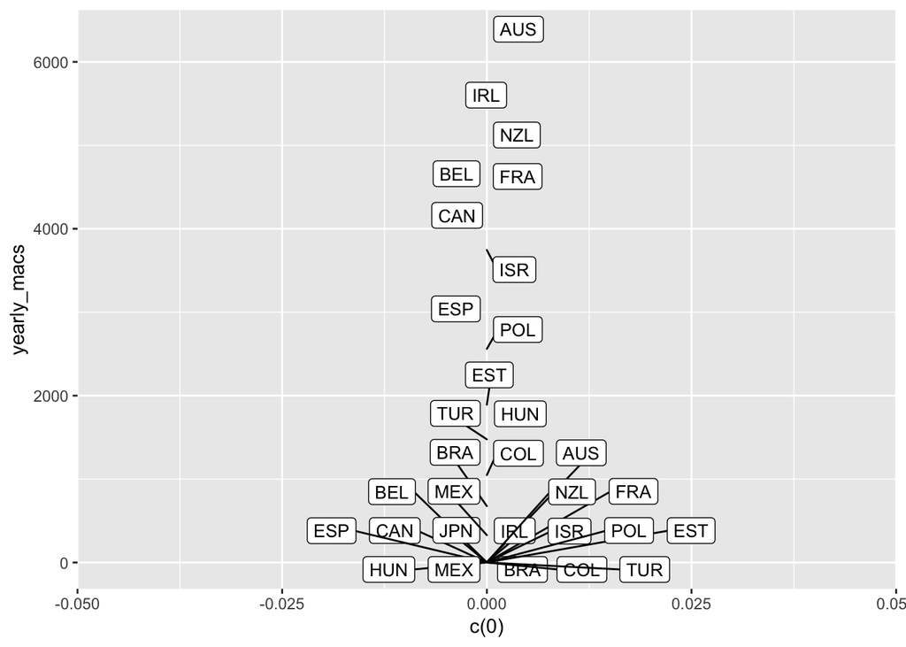

```r
latest_minimum_wage_data <- latest_minimum_wage_data %>%
  inner_join(country_abbreviation, c("COUNTRY"="FIFA"))

minMac <- latest_minimum_wage_data %>%
  inner_join(mac_data, c("UNTERM English Short"="Country"))

minMac <- minMac %>%
  mutate(yearly_macs = Value / `Dollar Price`)

minMac %>%
  ggplot(aes(x=c(0), y=yearly_macs, label = COUNTRY)) + geom_label_repel(size = 3.5)
```

Here we can see how Australia is now on top, followed by Ireland. It is important to mention that for this part of the project the total number of considered countries was reduced after the inner join. This ocurred because there was not a exact match between the two different ways to refer a country. E.i = United States and United States of America.

We plotted the same idea, but yearly. How many Big Macs can a minimum wage worker buy a year per country. ##Bibliography

[1] “Big MacCurrencies”. The Economist. 9 April 1998.